# wrdtp_2025-conference_8thjune

**Methods of Care and Hope**

**Can We Establish the Presence - or Absence - of Discrimination in Sentencing?**

Jose Pina-Sánchez

## Sentencing

- The strongest expression of the coercive powers of the state

  – clear material consequences

  – equally important symbolic value
- Over a million criminal cases sentenced every year

## Is justice really blind?

- Ministry of Justice (2016)

  – 2.4 higher odds of custody for minority offenders

  – convicted of a drug offence

  – conditioning on gender, age, previous convictions, and plea
- Is that evidence of discrimination?
- According to the literature: no definitive answer

  – every case is different

  – cannot condition on every relevant factor

# Methods to push the frontier of knowledge

## Judges are humans

- Individualisation is an aspiration

  – as demonstrated by the clustering of custodial sentences

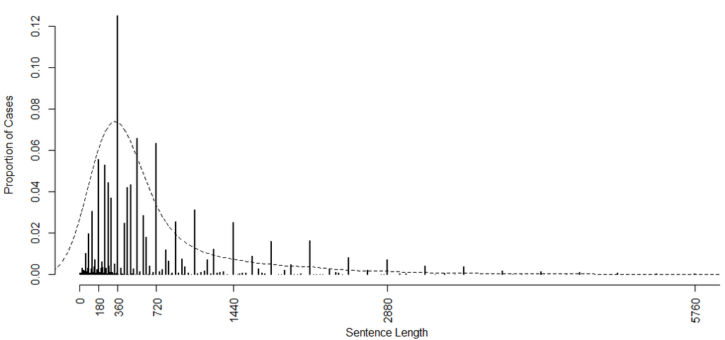

## Not all legal factors are race neutral

- Strongest disparities amongst offenders’ characteristics that are discretionally defined

  – remorse, good character, and potential for rehabilitation
- We might be controlling away what we seek to estimate

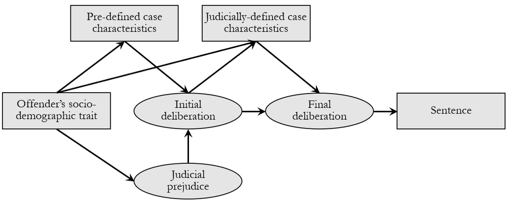

## Effect size matters

- Sensitivity analysis to redirect the burden of proof

  – which missing legal factor could explain those disparities?
- Strong disparities can only be explained if:

  – the missing legal factors are exerting a large influence

  – and they are unevenly distributed amongst ethnic groups

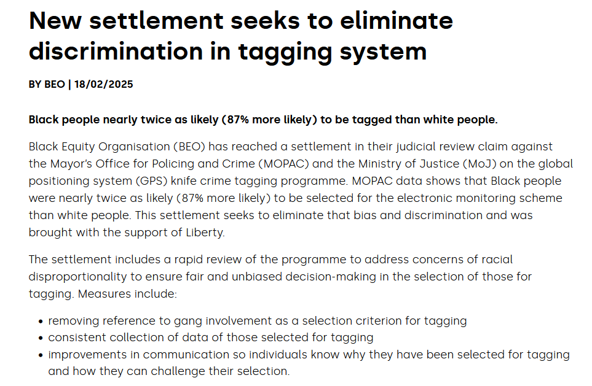

# Methods to avoid fooling ourselves

## Publication bias & cherry picking

- ‘Race studies’ show twice stronger disparities than other sentencing studies
- MoJ (2016) did not find disparities for violence or sex offences

  – yet, those findings are systematically ignored
- We only find disparities in 1 out of 9 offence groups

## Unintended consequences

- If we claim there is discrimination when there is not

  – we undermine trust in the criminal justice system

  – alienate minority groups

## Change of research culture

- Slow research

  – quality over quantity
- Open research

  – registered reports
- Normalise contradictions

  – social reality is messy

  – ‘story telling’ is not always helpful

# Through careful methods we can build a more hopeful future